# R Bootcamp - List of Functions

Tu Tran und Andy Gubser

19 February, 2020

# 1 R Markdown

```r
knitr::opts_chunk$set(echo = TRUE, include=TRUE)
```

- The Definitive Guide: https://bookdown.org/yihui/rmarkdown/
- R Markdown Cheat Sheet: https://rstudio.com/wp-content/uploads/2016/03/rmarkdown-cheatsheet-2.0.pdf
- R Markdown Reference Guide: https://rstudio.com/wp-content/uploads/2015/03/rmarkdown-reference.pdf

# 2 Base R

## 2.1 Global Environment

```r
apropos("filter")
```

```
[1] "filter"      "Filter"      "Filters"     "knit_filter"
```

```r
apropos("filter", where = TRUE)
```

```
            3            10             6             2
     "filter"      "Filter"     "Filters" "knit_filter"
```

```r
pos.to.env(4) ## or search()
```

```
<environment: package:graphics>
attr(,"name")
[1] "package:graphics"
attr(,"path")
[1] "C:/Program Files/R/R-3.6.1/library/graphics"
```

```r
pos.to.env(6)
```

```
<environment: package:utils>
attr(,"name")
[1] "package:utils"
attr(,"path")
[1] "C:/Program Files/R/R-3.6.1/library/utils"
```

## 2.2 Matrices

```r
# create a matrix
M.1 <- matrix(data = 6:1, nrow = 2, ncol = 3)
M.1
```

```
     [,1] [,2] [,3]
[1,]    6    4    2
[2,]    5    3    1
```

```r
# equivalent to
rbind(c(6,4,2), c(5,3,1))
```

```
     [,1] [,2] [,3]
[1,]    6    4    2
[2,]    5    3    1
```

```r
cbind(1:2, 3:4, 5:6)
```

```
     [,1] [,2] [,3]
[1,]    1    3    5
[2,]    2    4    6
```

```r
# add a column to existing matrix
cbind(M.1, c(99, 102))
```

```
     [,1] [,2] [,3] [,4]
[1,]    6    4    2   99
[2,]    5    3    1  102
```

```r
# replace()
```

## 2.3 Data Frames

```r
## creating a data frame
v.participant.name <- c("Max", "Tony Müller", "Andreas", "Ramona", "Nick Q.")
v.age <- c(17, 23, 45, 11, 44)
v.minor.YES <- c(TRUE, FALSE, FALSE, TRUE, FALSE)
d.test <- data.frame(v.participant.name, v.age, v.minor.YES)
d.test
```

| v.participant.name | v.age | v.minor.YES |
| --- | --- | --- |
| Max | 17 | TRUE |
| Tony Müller | 23 | FALSE |
| Andreas | 45 | FALSE |
| Ramona | 11 | TRUE |
| Nick Q. | 44 | FALSE |

```r
## class of the single elements
class(v.participant.name)
```

```
[1] "character"
```

```r
class(v.age)
```

```
[1] "numeric"
```

```r
class(v.minor.YES)
```

```
[1] "logical"
```

```r
class(d.test)
```

```
[1] "data.frame"
```

```r
## Attributes
colnames(d.test)
```

```
[1] "v.participant.name" "v.age"              "v.minor.YES"
```

```r
rownames(d.test)
```

```
[1] "1" "2" "3" "4" "5"
```

```r
# tibble::rownames_to_column(d.sports)
```

## 2.4 Functions

```r
## help pages
#?mean
#help(mean)
## ...using the Rstudio "help" pane

# list all elements in global environment
ls()
```

```
[1] "d.test"             "M.1"                "v.age"
[4] "v.minor.YES"        "v.participant.name"
```

```r
## create sequences
seq(from = 1, to = 10, length.out = 5)
```

```
[1]  1.0  3.2  5.5  7.8 10.0
```

```r
rep(x = 1:3, times = 4)
```

```
 [1] 1 2 3 1 2 3 1 2 3 1 2 3
```

## 2.5 Methods

```r
lm.iris <- lm(Sepal.Width ~ Species, data = iris)
summary(lm.iris)
```

```
Call:
lm(formula = Sepal.Width ~ Species, data = iris)

Residuals:
   Min     1Q Median     3Q    Max
-1.128 -0.228  0.026  0.226  0.972

Coefficients:
                  Estimate Std. Error t value Pr(>|t|)
(Intercept)         3.4280     0.0480   71.36  < 2e-16 ***
Speciesversicolor  -0.6580     0.0679   -9.69  < 2e-16 ***
Speciesvirginica   -0.4540     0.0679   -6.68  4.5e-10 ***
---
Signif. codes:  0 '***' 0.001 '**' 0.01 '*' 0.05 '.' 0.1 ' ' 1

Residual standard error: 0.34 on 147 degrees of freedom
Multiple R-squared:  0.401, Adjusted R-squared:  0.393
F-statistic: 49.2 on 2 and 147 DF,  p-value: <2e-16
```

```r
methods(summary)
```

```
 [1] summary.aov                    summary.aovlist*
 [3] summary.aspell*                summary.check_packages_in_dir*
 [5] summary.connection             summary.data.frame
 [7] summary.Date                   summary.default
 [9] summary.ecdf*                  summary.factor
[11] summary.glm                    summary.infl*
[13] summary.lm                     summary.loess*
[15] summary.manova                 summary.matrix
[17] summary.mlm*                   summary.nls*
[19] summary.packageStatus*         summary.POSIXct
[21] summary.POSIXlt                summary.ppr*
[23] summary.prcomp*                summary.princomp*
[25] summary.proc_time              summary.rlang_error*
[27] summary.rlang_trace*           summary.srcfile
[29] summary.srcref                 summary.stepfun
[31] summary.stl*                   summary.table
[33] summary.tukeysmooth*           summary.warnings
see '?methods' for accessing help and source code
```

```r
methods(class = "lm")
```

```
 [1] add1           alias          anova          case.names     coerce
 [6] confint        cooks.distance deviance       dfbeta         dfbetas
[11] drop1          dummy.coef     effects        extractAIC     family
[16] formula        hatvalues      influence      initialize     kappa
[21] labels         logLik         model.frame    model.matrix   nobs
[26] plot           predict        print          proj           qr
[31] residuals      rstandard      rstudent       show           simulate
[36] slotsFromS3    summary        variable.names vcov
see '?methods' for accessing help and source code
```

```r
methods(class = "matrix")
```

```
 [1] anyDuplicated as.data.frame as.raster     boxplot       coerce
 [6] determinant   duplicated    edit          head          initialize
[11] isSymmetric   Math          Math2         Ops           relist
[16] subset        summary       tail          unique
see '?methods' for accessing help and source code
```

```r
methods(write.csv) # not a generic function
```

```
no methods found
```

# 3 Import Data

```r
## set and get working directory
setwd(getwd())

## import data
d.blueEggs <- read.table("../DataSets/BlaueEier.txt",
           header = TRUE)
d.sports <- read.table("http://stat.ethz.ch/Teaching/Datasets/sport.dat",
                       header = TRUE)

## writing/creating data files
# write.csv2(d.sports, "SportsDataset.csv")
# write.csv()
# write.table()
```

# 4 Inspect Data

```r
## inspect data
str(iris)
```

```
'data.frame':   150 obs. of  5 variables:
 $ Sepal.Length: num  5.1 4.9 4.7 4.6 5 5.4 4.6 5 4.4 4.9 ...
 $ Sepal.Width : num  3.5 3 3.2 3.1 3.6 3.9 3.4 3.4 2.9 3.1 ...
 $ Petal.Length: num  1.4 1.4 1.3 1.5 1.4 1.7 1.4 1.5 1.4 1.5 ...
 $ Petal.Width : num  0.2 0.2 0.2 0.2 0.2 0.4 0.3 0.2 0.2 0.1 ...
 $ Species     : Factor w/ 3 levels "setosa","versicolor",..: 1 1 1 1 1 1 1 1 1 1 ...
```

```r
dim(iris) ## nrow(iris); ncol(iris)
```

```
[1] 150   5
```

```r
head(iris)
```

|  | Sepal.Length | Sepal.Width | Petal.Length | Petal.Width | Species |
| --- | --- | --- | --- | --- | --- |
| 1 | 5.1 | 3.5 | 1.4 | 0.2 | setosa |
| 2 | 4.9 | 3.0 | 1.4 | 0.2 | setosa |
| 3 | 4.7 | 3.2 | 1.3 | 0.2 | setosa |
| 4 | 4.6 | 3.1 | 1.5 | 0.2 | setosa |
| 5 | 5.0 | 3.6 | 1.4 | 0.2 | setosa |
| 6 | 5.4 | 3.9 | 1.7 | 0.4 | setosa |

```r
summary(iris)
```

```
  Sepal.Length  Sepal.Width   Petal.Length  Petal.Width        Species
 Min.   :4.3   Min.   :2.0   Min.   :1.0   Min.   :0.1   setosa    :50
 1st Qu.:5.1   1st Qu.:2.8   1st Qu.:1.6   1st Qu.:0.3   versicolor:50
 Median :5.8   Median :3.0   Median :4.3   Median :1.3   virginica :50
 Mean   :5.8   Mean   :3.1   Mean   :3.8   Mean   :1.2
 3rd Qu.:6.4   3rd Qu.:3.3   3rd Qu.:5.1   3rd Qu.:1.8
 Max.   :7.9   Max.   :4.4   Max.   :6.9   Max.   :2.5
```

```r
table(iris[, "Species"])
```

```
    setosa versicolor  virginica
        50         50         50
```

```r
min(iris$Sepal.Length)
```

```
[1] 4.3
```

```r
max(iris$Sepal.Length)
```

```
[1] 7.9
```

```r
mean(x = 1:13)
```

```
[1] 7
```

```r
range(iris$Sepal.Length)
```

```
[1] 4.3 7.9
```

```r
levels(iris$Species)
```

```
[1] "setosa"     "versicolor" "virginica"
```

```r
nlevels(iris$Species)
```

```
[1] 3
```

```r
length(unique(iris$Sepal.Length))
```

```
[1] 35
```

```r
## see also n_distinct() in package {dplyr}
```

# 5 Data Preprocessing

## 5.1 Mutate, Filter, Arange, Select with {dplyr}

```r
library(dplyr)
d.sports <- tibble::rownames_to_column(d.sports)

d.sports %>%
  mutate(weit.in.cm = weit*100) %>%
#  select(d.sports, contains("e"))
#                  starts_with(...)
#                  ends_with(...)
  filter(hoch > 200, weit.in.cm >= 780) %>% # filter observations
  arrange(hoch, desc(weit.in.cm)) %>% # sort observations
  select(rowname, weit.in.cm, hoch, punkte) %>%  # select variables
  head
```

|  | rowname | weit.in.cm | hoch | punkte |
| --- | --- | --- | --- | --- |
| 1 | NOOL | 788 | 201 | 8543 |
| 2 | BUSEMANN | 807 | 204 | 8706 |
| 3 | PLAZIAT | 782 | 204 | 8282 |

```r
## sample observations
## select random rows from a table
head(d.sports)
```

|  | rowname | weit | kugel | hoch | disc | stab | speer | punkte |
| --- | --- | --- | --- | --- | --- | --- | --- | --- |
| 1 | OBRIEN | 7.6 | 16 | 207 | 49 | 500 | 67 | 8824 |
| 2 | BUSEMANN | 8.1 | 14 | 204 | 45 | 480 | 67 | 8706 |
| 3 | DVORAK | 7.6 | 16 | 198 | 46 | 470 | 70 | 8664 |
| 4 | FRITZ | 7.8 | 15 | 204 | 50 | 510 | 66 | 8644 |
| 5 | HAMALAINEN | 7.5 | 16 | 198 | 50 | 500 | 58 | 8613 |
| 6 | NOOL | 7.9 | 14 | 201 | 43 | 540 | 65 | 8543 |

```r
sample_n(d.sports, size = 10)
```

| rowname | weit | kugel | hoch | disc | stab | speer | punkte |
| --- | --- | --- | --- | --- | --- | --- | --- |
| SMITH | 7.5 | 17 | 195 | 50 | 500 | 64 | 8271 |
| PLAZIAT | 7.8 | 15 | 204 | 45 | 490 | 52 | 8282 |
| ZMELIK | 7.6 | 14 | 195 | 43 | 540 | 67 | 8422 |
| NOOL | 7.9 | 14 | 201 | 43 | 540 | 65 | 8543 |
| PENALVER | 7.3 | 17 | 207 | 49 | 470 | 57 | 8307 |
| MAGNUSSON | 7.3 | 16 | 195 | 44 | 480 | 61 | 8274 |
| BUSEMANN | 8.1 | 14 | 204 | 45 | 480 | 67 | 8706 |
| CHMARA | 7.8 | 15 | 210 | 43 | 490 | 55 | 8249 |
| HAMALAINEN | 7.5 | 16 | 198 | 50 | 500 | 58 | 8613 |
| GANIYEV | 7.6 | 15 | 213 | 45 | 520 | 54 | 8318 |

```r
sample_frac(d.sports, size = 0.2)
```

| rowname | weit | kugel | hoch | disc | stab | speer | punkte |
| --- | --- | --- | --- | --- | --- | --- | --- |
| HUFFINS | 7.5 | 16 | 204 | 49 | 470 | 61 | 8300 |
| CHMARA | 7.8 | 15 | 210 | 43 | 490 | 55 | 8249 |
| NOOL | 7.9 | 14 | 201 | 43 | 540 | 65 | 8543 |

### 5.1.1 Replace NA with {tidyr}

```r
d.sports.NA <- d.sports
d.sports.NA[1:2, "weit"] <- NA
d.sports.NA[3:6, "kugel"] <- NA
d.sports.NA
```

| rowname | weit | kugel | hoch | disc | stab | speer | punkte |
| --- | --- | --- | --- | --- | --- | --- | --- |
| OBRIEN | NA | 16 | 207 | 49 | 500 | 67 | 8824 |
| BUSEMANN | NA | 14 | 204 | 45 | 480 | 67 | 8706 |
| DVORAK | 7.6 | NA | 198 | 46 | 470 | 70 | 8664 |
| FRITZ | 7.8 | NA | 204 | 50 | 510 | 66 | 8644 |
| HAMALAINEN | 7.5 | NA | 198 | 50 | 500 | 58 | 8613 |
| NOOL | 7.9 | NA | 201 | 43 | 540 | 65 | 8543 |
| ZMELIK | 7.6 | 14 | 195 | 43 | 540 | 67 | 8422 |
| GANIYEV | 7.6 | 15 | 213 | 45 | 520 | 54 | 8318 |
| PENALVER | 7.3 | 17 | 207 | 49 | 470 | 57 | 8307 |
| HUFFINS | 7.5 | 16 | 204 | 49 | 470 | 61 | 8300 |

[output cut: 5 more lines]

```r
library(tidyr)
replace_na(d.sports.NA,
           list(weit = 2, kugel = 10)) %>%
  head
```

|  | rowname | weit | kugel | hoch | disc | stab | speer | punkte |
| --- | --- | --- | --- | --- | --- | --- | --- | --- |
| 1 | OBRIEN | 2.0 | 16 | 207 | 49 | 500 | 67 | 8824 |
| 2 | BUSEMANN | 2.0 | 14 | 204 | 45 | 480 | 67 | 8706 |
| 3 | DVORAK | 7.6 | 10 | 198 | 46 | 470 | 70 | 8664 |
| 4 | FRITZ | 7.8 | 10 | 204 | 50 | 510 | 66 | 8644 |
| 5 | HAMALAINEN | 7.5 | 10 | 198 | 50 | 500 | 58 | 8613 |
| 6 | NOOL | 7.9 | 10 | 201 | 43 | 540 | 65 | 8543 |

# 6 Data Analysis

## 6.1 Deskriptive Analysis

```r
## summarise data
head(iris)
```

|  | Sepal.Length | Sepal.Width | Petal.Length | Petal.Width | Species |
| --- | --- | --- | --- | --- | --- |
| 1 | 5.1 | 3.5 | 1.4 | 0.2 | setosa |
| 2 | 4.9 | 3.0 | 1.4 | 0.2 | setosa |
| 3 | 4.7 | 3.2 | 1.3 | 0.2 | setosa |
| 4 | 4.6 | 3.1 | 1.5 | 0.2 | setosa |
| 5 | 5.0 | 3.6 | 1.4 | 0.2 | setosa |
| 6 | 5.4 | 3.9 | 1.7 | 0.4 | setosa |

```r
iris %>%
  summarise(mean.SepalLength = mean(Sepal.Length))
```

| mean.SepalLength |
| --- |
| 5.8 |

```r
## summarise per group
iris %>%
  group_by(Species) %>%
  summarise(mean.SepalLength = mean(Sepal.Length))
```

| Species | mean.SepalLength |
| --- | --- |
| setosa | 5.0 |
| versicolor | 5.9 |
| virginica | 6.6 |

```r
## get top n observations
iris %>%
  group_by(Species) %>%
  top_n(n = 2, wt = Sepal.Length) ## by default wt is the last column
```

| Sepal.Length | Sepal.Width | Petal.Length | Petal.Width | Species |
| --- | --- | --- | --- | --- |
| 5.8 | 4.0 | 1.2 | 0.2 | setosa |
| 5.7 | 4.4 | 1.5 | 0.4 | setosa |
| 5.7 | 3.8 | 1.7 | 0.3 | setosa |
| 7.0 | 3.2 | 4.7 | 1.4 | versicolor |
| 6.9 | 3.1 | 4.9 | 1.5 | versicolor |
| 7.7 | 3.8 | 6.7 | 2.2 | virginica |
| 7.7 | 2.6 | 6.9 | 2.3 | virginica |
| 7.7 | 2.8 | 6.7 | 2.0 | virginica |
| 7.9 | 3.8 | 6.4 | 2.0 | virginica |
| 7.7 | 3.0 | 6.1 | 2.3 | virginica |

```r
## counting observations
iris %>%
  group_by(Species) %>%
  summarise(No.Obs = n())
```

| Species | No.Obs |
| --- | --- |
| setosa | 50 |
| versicolor | 50 |
| virginica | 50 |

```r
## adding a counter
iris %>%
  mutate(id = 1:n())
```

| Sepal.Length | Sepal.Width | Petal.Length | Petal.Width | Species | id |
| --- | --- | --- | --- | --- | --- |
| 5.1 | 3.5 | 1.4 | 0.2 | setosa | 1 |
| 4.9 | 3.0 | 1.4 | 0.2 | setosa | 2 |
| 4.7 | 3.2 | 1.3 | 0.2 | setosa | 3 |
| 4.6 | 3.1 | 1.5 | 0.2 | setosa | 4 |
| 5.0 | 3.6 | 1.4 | 0.2 | setosa | 5 |
| 5.4 | 3.9 | 1.7 | 0.4 | setosa | 6 |
| 4.6 | 3.4 | 1.4 | 0.3 | setosa | 7 |
| 5.0 | 3.4 | 1.5 | 0.2 | setosa | 8 |
| 4.4 | 2.9 | 1.4 | 0.2 | setosa | 9 |
| 4.9 | 3.1 | 1.5 | 0.1 | setosa | 10 |

[output cut: 140 more lines]

```r
## adding a counter within group
iris %>%
  group_by(Species) %>%
  mutate(id = 1:n())
```

| Sepal.Length | Sepal.Width | Petal.Length | Petal.Width | Species | id |
| --- | --- | --- | --- | --- | --- |
| 5.1 | 3.5 | 1.4 | 0.2 | setosa | 1 |
| 4.9 | 3.0 | 1.4 | 0.2 | setosa | 2 |
| 4.7 | 3.2 | 1.3 | 0.2 | setosa | 3 |
| 4.6 | 3.1 | 1.5 | 0.2 | setosa | 4 |
| 5.0 | 3.6 | 1.4 | 0.2 | setosa | 5 |
| 5.4 | 3.9 | 1.7 | 0.4 | setosa | 6 |
| 4.6 | 3.4 | 1.4 | 0.3 | setosa | 7 |
| 5.0 | 3.4 | 1.5 | 0.2 | setosa | 8 |
| 4.4 | 2.9 | 1.4 | 0.2 | setosa | 9 |
| 4.9 | 3.1 | 1.5 | 0.1 | setosa | 10 |

[output cut: 140 more lines]

```r
## forcing printing
iris %>%
  group_by(Species) %>%
  mutate(id = 1:n()) %>%
  print(width = Inf, n = 51)
```

```
# A tibble: 150 x 6
# Groups:   Species [3]
   Sepal.Length Sepal.Width Petal.Length Petal.Width Species       id
          <dbl>       <dbl>        <dbl>       <dbl> <fct>      <int>
 1          5.1         3.5          1.4         0.2 setosa         1
 2          4.9         3            1.4         0.2 setosa         2
 3          4.7         3.2          1.3         0.2 setosa         3
 4          4.6         3.1          1.5         0.2 setosa         4
 5          5           3.6          1.4         0.2 setosa         5
 6          5.4         3.9          1.7         0.4 setosa         6
 7          4.6         3.4          1.4         0.3 setosa         7
 8          5           3.4          1.5         0.2 setosa         8
 9          4.4         2.9          1.4         0.2 setosa         9
10          4.9         3.1          1.5         0.1 setosa        10
11          5.4         3.7          1.5         0.2 setosa        11
```

[output cut: 41 more lines]

## 6.2 Regression Analysis

```r
## Generic and methods functions
lm.1 <- lm(Sepal.Length ~ Petal.Length,
           data = iris)
summary(lm.1)
```

```
Call:
lm(formula = Sepal.Length ~ Petal.Length, data = iris)

Residuals:
    Min      1Q  Median      3Q     Max
-1.2468 -0.2966 -0.0152  0.2768  1.0027

Coefficients:
             Estimate Std. Error t value Pr(>|t|)
(Intercept)    4.3066     0.0784    54.9   <2e-16 ***
Petal.Length   0.4089     0.0189    21.6   <2e-16 ***
---
Signif. codes:  0 '***' 0.001 '**' 0.01 '*' 0.05 '.' 0.1 ' ' 1

Residual standard error: 0.41 on 148 degrees of freedom
Multiple R-squared:  0.76,  Adjusted R-squared:  0.758
F-statistic:  469 on 1 and 148 DF,  p-value: <2e-16
```

```r
summary(iris)
```

```
  Sepal.Length  Sepal.Width   Petal.Length  Petal.Width        Species
 Min.   :4.3   Min.   :2.0   Min.   :1.0   Min.   :0.1   setosa    :50
 1st Qu.:5.1   1st Qu.:2.8   1st Qu.:1.6   1st Qu.:0.3   versicolor:50
 Median :5.8   Median :3.0   Median :4.3   Median :1.3   virginica :50
 Mean   :5.8   Mean   :3.1   Mean   :3.8   Mean   :1.2
 3rd Qu.:6.4   3rd Qu.:3.3   3rd Qu.:5.1   3rd Qu.:1.8
 Max.   :7.9   Max.   :4.4   Max.   :6.9   Max.   :2.5
```

```r
## same function , different behaviour?
## --> summary is a generic function
class(lm.1)
```

```
[1] "lm"
```

```r
methods(summary)
```

```
 [1] summary.aov                    summary.aovlist*
 [3] summary.aspell*                summary.check_packages_in_dir*
 [5] summary.connection             summary.data.frame
 [7] summary.Date                   summary.default
 [9] summary.ecdf*                  summary.factor
[11] summary.glm                    summary.infl*
[13] summary.lm                     summary.loess*
[15] summary.manova                 summary.matrix
[17] summary.mlm*                   summary.nls*
[19] summary.packageStatus*         summary.POSIXct
[21] summary.POSIXlt                summary.ppr*
[23] summary.prcomp*                summary.princomp*
[25] summary.proc_time              summary.rlang_error*
[27] summary.rlang_trace*           summary.srcfile
[29] summary.srcref                 summary.stepfun
[31] summary.stl*                   summary.table
[33] summary.tukeysmooth*           summary.vctrs_sclr*
[35] summary.vctrs_vctr*            summary.warnings
see '?methods' for accessing help and source code
```

```r
methods(class = "lm")
```

```
 [1] add1           alias          anova          case.names     coerce
 [6] confint        cooks.distance deviance       dfbeta         dfbetas
[11] drop1          dummy.coef     effects        extractAIC     family
[16] formula        hatvalues      influence      initialize     kappa
[21] labels         logLik         model.frame    model.matrix   nobs
[26] plot           predict        print          proj           qr
[31] residuals      rstandard      rstudent       show           simulate
[36] slotsFromS3    summary        variable.names vcov
see '?methods' for accessing help and source code
```

```r
?summary.lm ## has its own help page
?summary.data.frame ## redirects you to the *generic* function help page
```

# 7 Data Visualisation

## 7.1 Base R plot function

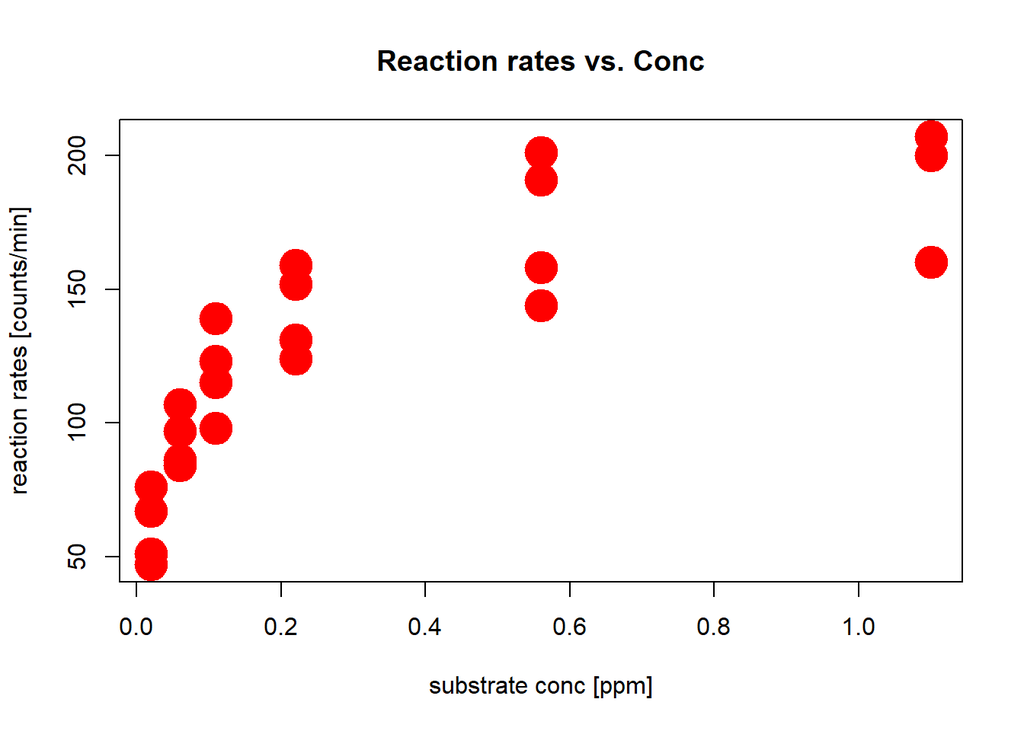

```r
d.Puromycin.plot <- plot(y = Puromycin$rate,
     x = Puromycin$conc,
     pch = 19, # pch 19 is a filled circle
     col = "red", # set color
     cex = 3, # set point size

     # add a title and axis labels
     main = "Reaction rates vs. Conc",
     xlab = "substrate conc [ppm]",
     ylab = "reaction rates [counts/min]",
     type = "p")
```

```r
# type = "l" # lines
# type = "b" # both (points and lines)
# type = "n" # nothing
# lty = "dashed") # line types

## formula interface
# plot(rate ~ conc, data = Puromycin)

# graphical parameters
graphical.parameters <- par()
head(graphical.parameters)
```

```
$xlog
[1] FALSE

$ylog
[1] FALSE

$adj
[1] 0.5

$ann
[1] TRUE

$ask
[1] FALSE

$bg
[1] "white"
```

```r
str(graphical.parameters)
```

```
List of 72
 $ xlog     : logi FALSE
 $ ylog     : logi FALSE
 $ adj      : num 0.5
 $ ann      : logi TRUE
 $ ask      : logi FALSE
 $ bg       : chr "white"
 $ bty      : chr "o"
 $ cex      : num 1
 $ cex.axis : num 1
 $ cex.lab  : num 1
 $ cex.main : num 1.2
 $ cex.sub  : num 1
 $ cin      : num [1:2] 0.15 0.2
 $ col      : chr "black"
```

[output cut: 58 more lines]

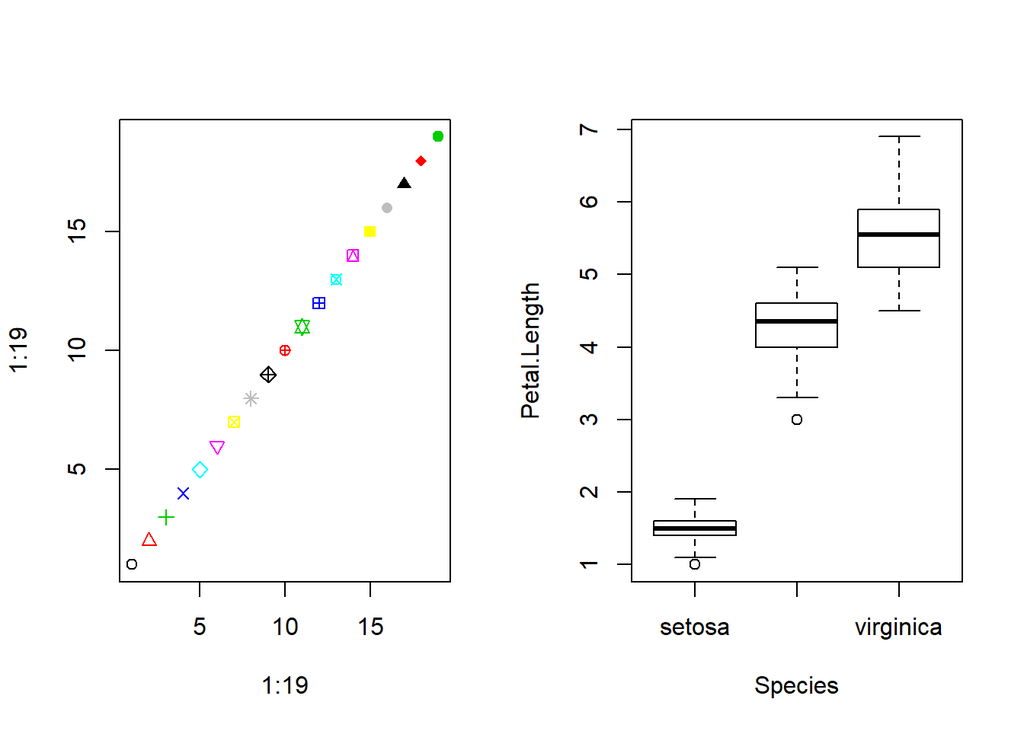

```r
# multiple plots on one screen
par(mfrow = c(1, 2))
plot(1:19, 1:19, pch = 1:19, col = 1:19)
boxplot(Petal.Length ~ Species, data = iris)
```

```r
## get back to default values
# dev.off()

## interactive functions ##
## identify
plot(Agriculture ~ Fertility, data = swiss)
identify(y = swiss$Agriculture, x = swiss$Fertility)
```

```
integer(0)
```

```r
## click on "finish" icon
swiss[c(46,19,7), ]
```

|  | Fertility | Agriculture | Examination | Education | Catholic | Infant.Mortality |
| --- | --- | --- | --- | --- | --- | --- |
| Rive Droite | 45 | 47 | 16 | 29 | 50.4 | 18 |
| La Vallee | 54 | 15 | 31 | 20 | 2.1 | 11 |
| Broye | 84 | 70 | 16 | 7 | 92.8 | 24 |

```r
## pannelling ##
head(Loblolly,  n = 8)
```

|  | height | age | Seed |
| --- | --- | --- | --- |
| 1 | 4.5 | 3 | 301 |
| 15 | 10.9 | 5 | 301 |
| 29 | 28.7 | 10 | 301 |
| 43 | 41.7 | 15 | 301 |
| 57 | 52.7 | 20 | 301 |
| 71 | 60.9 | 25 | 301 |
| 2 | 4.5 | 3 | 303 |
| 16 | 10.9 | 5 | 303 |

```r
levels(Loblolly$Seed)
```

```
 [1] "329" "327" "325" "307" "331" "311" "315" "321" "319" "301" "323" "309"
[13] "303" "305"
```

```r
nlevels(Loblolly$Seed)
```

```
[1] 14
```

```r
table(Loblolly$Seed)
```

```
329 327 325 307 331 311 315 321 319 301 323 309 303 305
  6   6   6   6   6   6   6   6   6   6   6   6   6   6
```

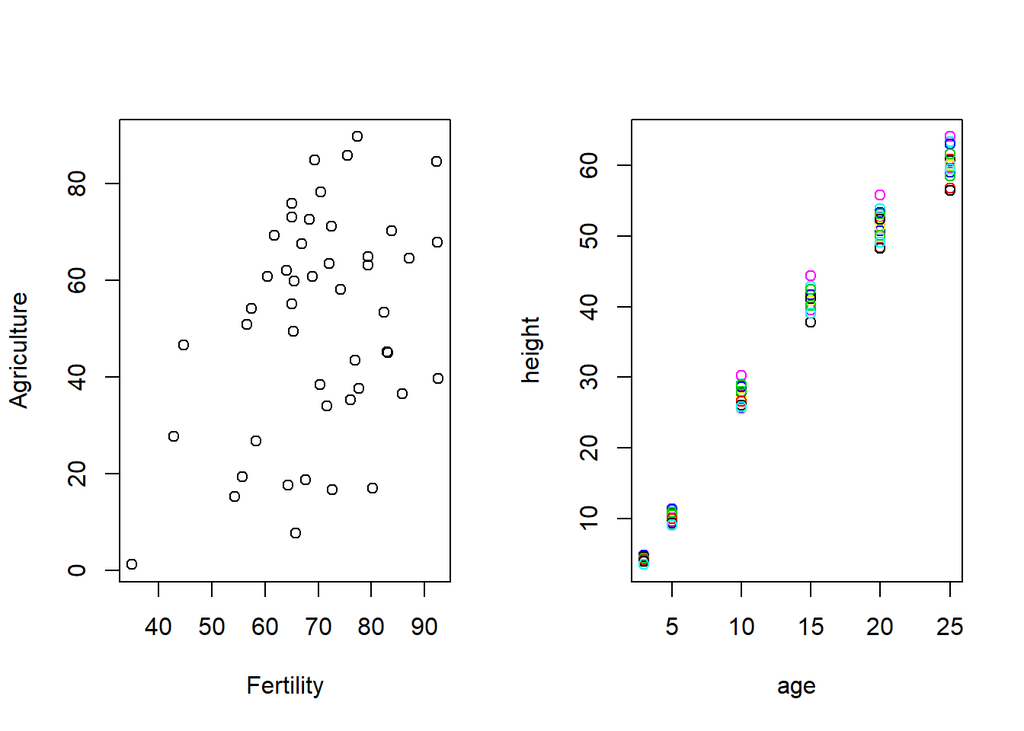

```r
plot(height ~ age, data = Loblolly, col = Seed)
```

## 7.2 Package {lattice}

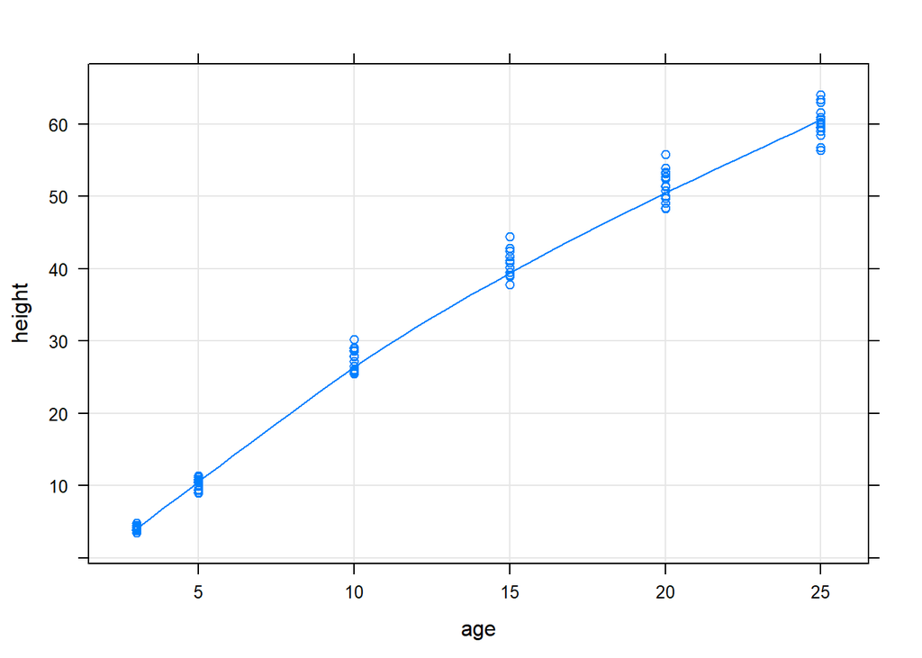

```r
library(lattice)
xyplot(height ~ age, data = Loblolly,
       type = c("p", "smooth", "g"))
```

```r
# "p": points
# "b"/"o": both (overplotted)
# "r": add linear regression line
# "smooth": add loess fit
# "spline": add cubic smoothing spline line
```

## 7.3 Package {ggplot2}

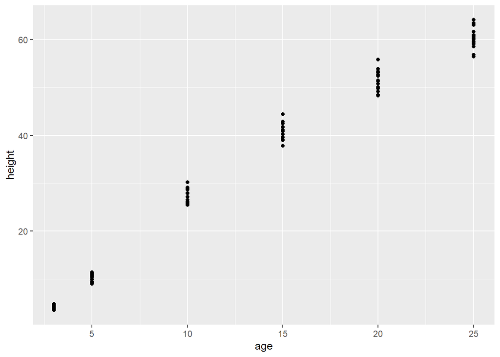

```r
## {ggplot2} ##
library(ggplot2)
## base call ggplot()
ggplot(data = Loblolly,
       mapping = aes(y = height,
                     x = age)) +
  geom_point()
```

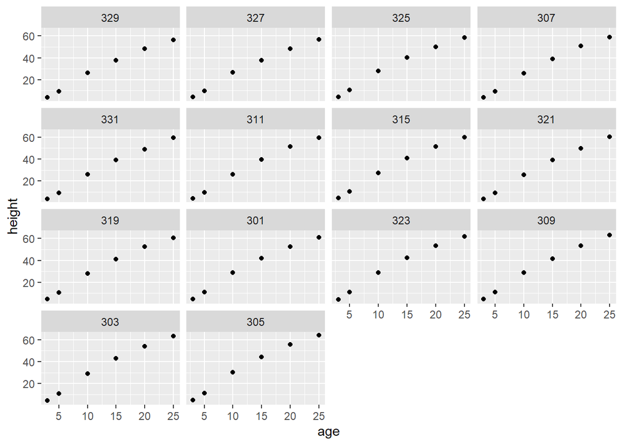

```r
## i) panelling
ggplot(data = Loblolly,
       mapping = aes(y = height,
                     x = age)) +
  geom_point() +
  facet_wrap(. ~ Seed) ## !
```

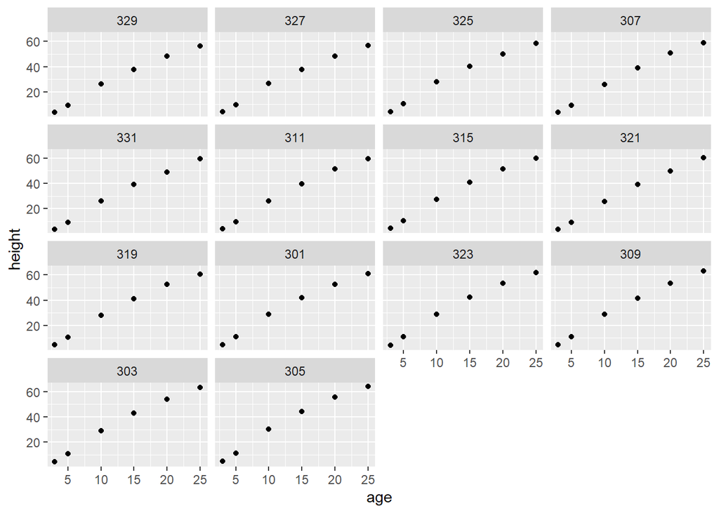

```r
# equivaltent to:
qplot(y = height, x = age, data = Loblolly, facets = ~ Seed)
```

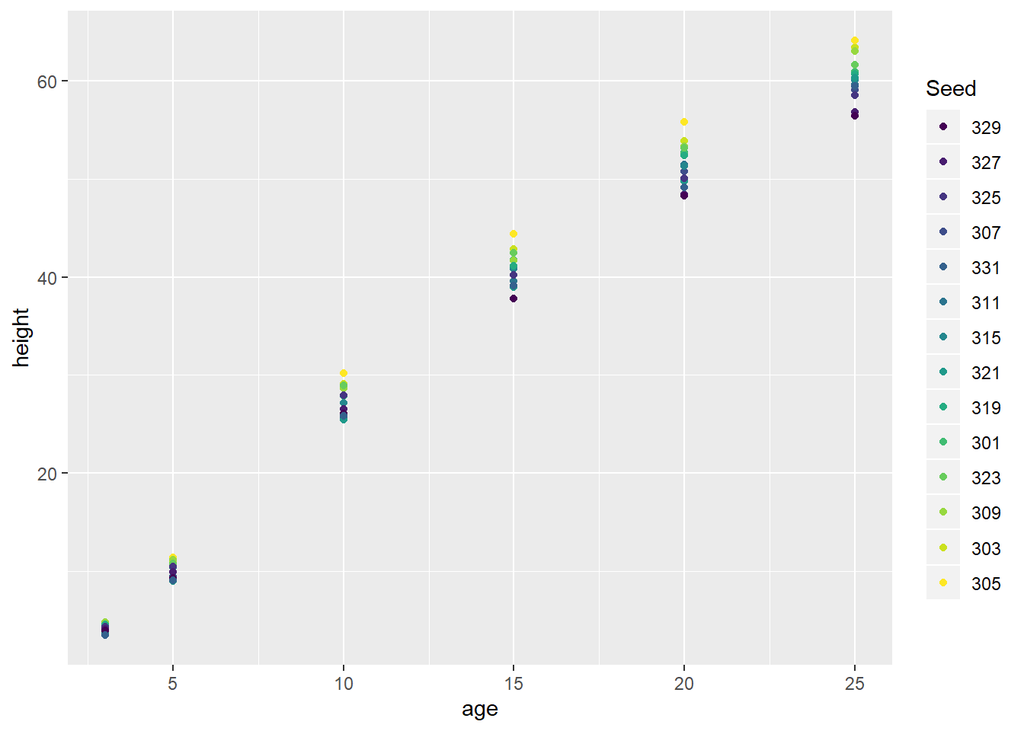

```r
## ii) grouping (colouring)
ggplot(data = Loblolly,
       mapping = aes(y = height,
                     x = age,
                     colour = Seed)) + ## !
  geom_point()
```

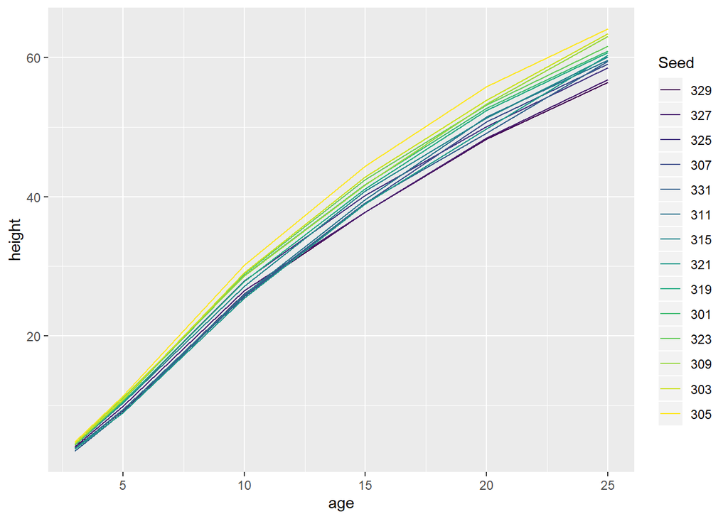

```r
##
ggplot(data = Loblolly,
       mapping = aes(y = height,
                     x = age,
                     colour = Seed)) +
  geom_line() ## !
```

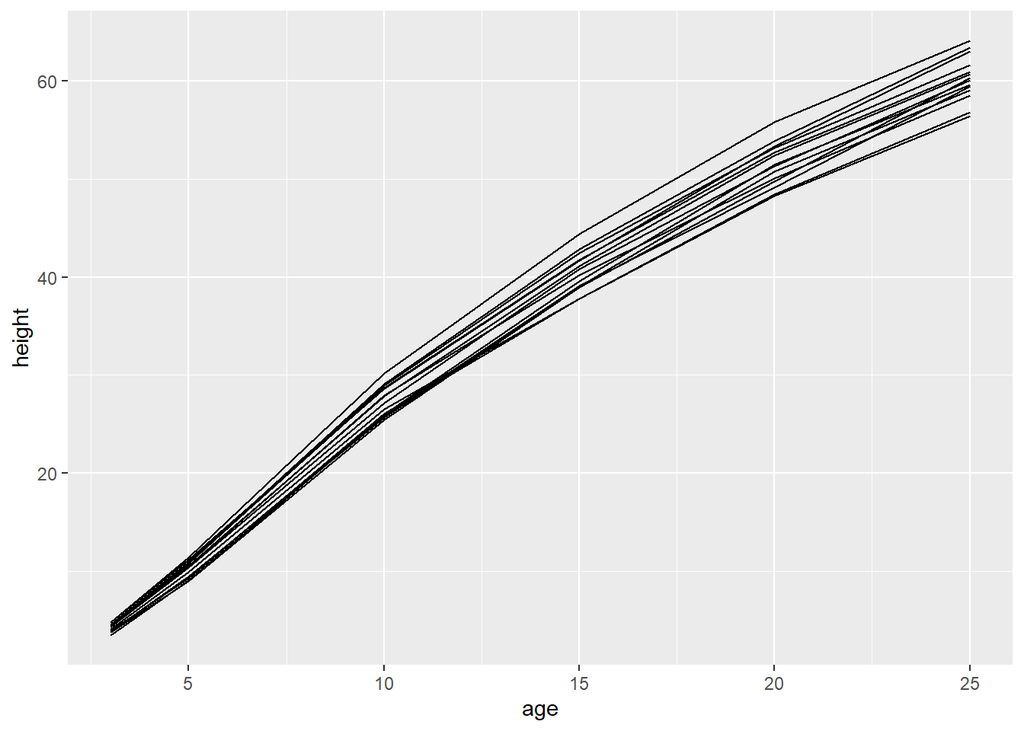

```r
## ii) grouping (no colouring)
ggplot(data = Loblolly,
       mapping = aes(y = height,
                     x = age,
                     group = Seed)) + ## !
  geom_line()
```

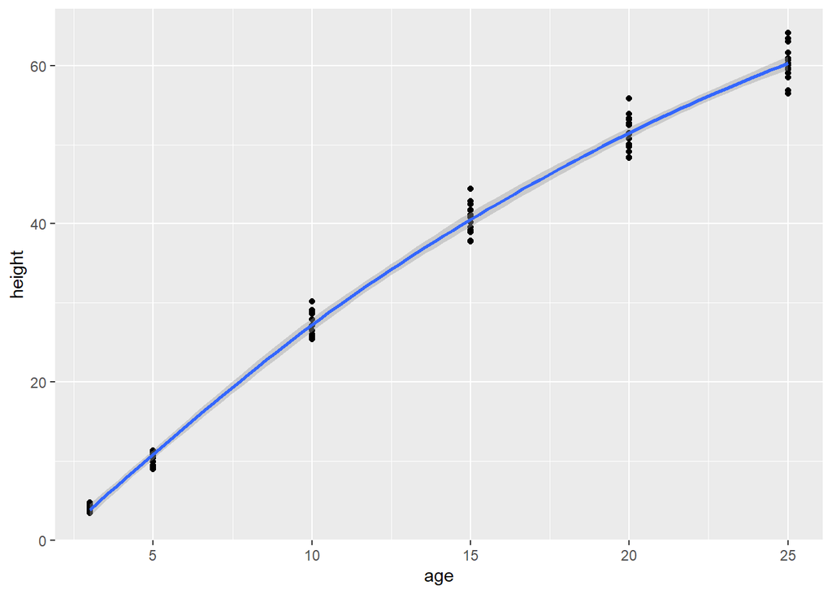

```r
## iii) adding summary statistics
ggplot(data = Loblolly,
       mapping = aes(y = height,
                     x = age)) +
  geom_point() +
  geom_smooth()
```

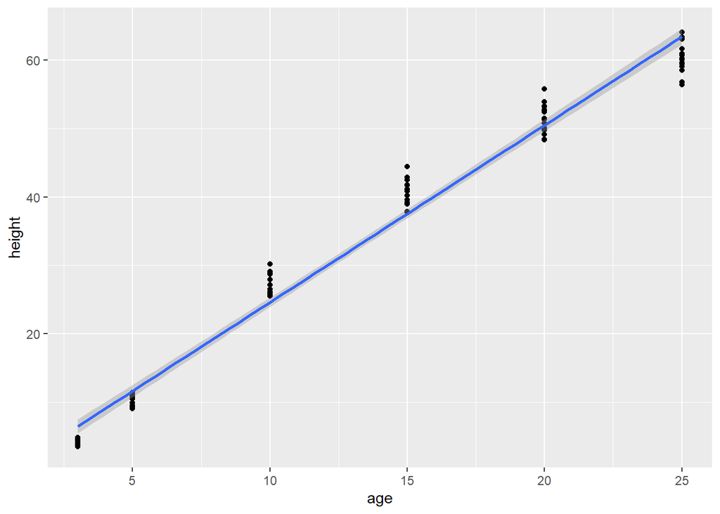

```r
##
ggplot(data = Loblolly,
       mapping = aes(y = height,
                     x = age)) +
  geom_point() +
  geom_smooth(method = "lm")
```

Here the link to the {ggplot2} Cheatsheet: https://github.com/rstudio/cheatsheets/blob/master/data-visualization-2.1.pdf

# 8 Regression Models

# 9 Packages

Load all packages at the very beginning of your code to avoid surprises and to get the function you want (e.g. base::filter() or mgcv::gam()

# 10 Best practices in Coding

## 10.1 Chunk structure

1. say what you will do (and why)
2. do it
3. check that it worked
4. comment the results

```r
## Example:
## we create a new variable that contains the results of "weit" expressed in cm
d.sports$weit.in.cm <- d.sports$weit
d.sports %>% select(contains("weit")) %>% sample_n(10)
```

| weit | weit.in.cm |
| --- | --- |
| 7.3 | 7.3 |
| 7.2 | 7.2 |
| 7.3 | 7.3 |
| 7.9 | 7.9 |
| 7.8 | 7.8 |
| 7.8 | 7.8 |
| 7.6 | 7.6 |
| 7.6 | 7.6 |
| 7.5 | 7.5 |
| 7.5 | 7.5 |

## 10.2 Saving and storing objects

```r
saveRDS(d.sports, file = "DSport.RDS")
## ensured to work well across different OS
```

## 10.3 Reproducibility

- rmarkdown/knitr files
- checkpoint package
- git

## 10.4 Coding conventions

Naming Objects: - d.xxx for data frame (e.g. d.sports) - v.xxx for vectors - t.xxx for temporary objects (e.g. in for loops) - lm.xxx for linear models objects - mod.xxx for other models (or e.g. svm.xxx for SVMs) - mod.sport.1 is usually less complex than mod.sport.2 - if your current model is e.g. mod.sport.4 and you compute say confidence intervals, name them ci.sport.4

## 10.5 overwriting

- y <- log(y) # worse bit of code you can write
- y.log <- log(y) # much better
- d.sports.weit.10 or d.sports.short <- d.sports %>% filer(weit >= 10)
- if adding variable to a data frame overwriting is ok
- d.sports <- d.sports %>%mutate(weit.in.cm = weit * 100)